# Enquête sur les téléspectateurs des séries tunisiennes ramadanesques

## Introduction:

Dans ce projet , on va présenter une enquête qui porte sur les séries tunisiennes et ses téléspectateurs. Ce projet comportera plusieurs analyses qui ont pour but de lier entre les variables et les individus et de les regroupés sous des catégories et aboutir à une conclusion ceci est par le biais d’une analyse des composantes principales et une analyse factorielle des correspondances ainsi qu’une description statiqtiques des données.

## Le questionnaire:

1.**La période d’enquête** : Avril-Mai 2021  
2.**L’enquête** : L’enquête a été crée par google Forms et distribuée aux repondeurs à travers **Facebook** , les données ont été aprés collectées dans un fichier excel et traitées par la suite par le langage R.  
3.**Base de données** : La base de données obtenue est une base de 245 lignes et 47 colonnes.

**Analyses:**

**Installation des packages:**

```r
#install.packages("FactoMineR")
#install.packages("factoextra")
#install.packages("readxl")
#install.packages("ggplot2")
#install.packages("stringr")
#install.packages("dplyr")
#install.packages("ggplot2")
#install.packages("ggrepel")
```

### Importation des données

```r
library(readxl)
data1 <- read_excel("C:\\Users\\azza\\Desktop\\analyse des donnees\\AD.xlsx")
df <- data.frame(data1)
```

### Transformation des données:

```r
colnames(df)[2]<-"sexe"
colnames(df)[3]<-"age"
colnames(df)[4]<-"csp"
colnames(df)[7]<-"serie"
colnames(df)[6]<-"genre"
```

### Statistique Descritpive:

Cette partie comportera une statistique descriptives des données de la base:  
**Etude du sexe:**

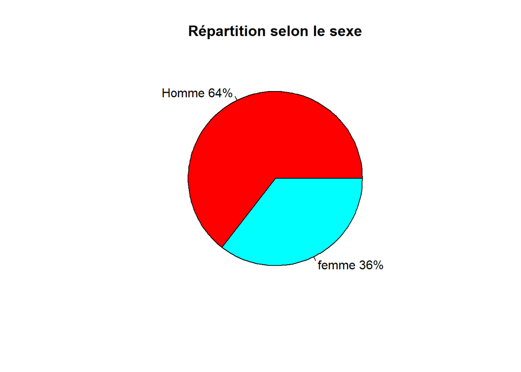

```r
sexe <- df$sexe
freq1=table(sexe)
pct1 <- round(freq1/sum(freq1)*100)
lbls1 <- c("Homme","femme")
lbls1 <- paste(lbls1, pct1)
lbls1 <- paste(lbls1,"%",sep="")
pie(freq1,labels = lbls1, col=rainbow(length(lbls1)),main="Répartition selon le sexe")
```

**Etude des classe âge:**

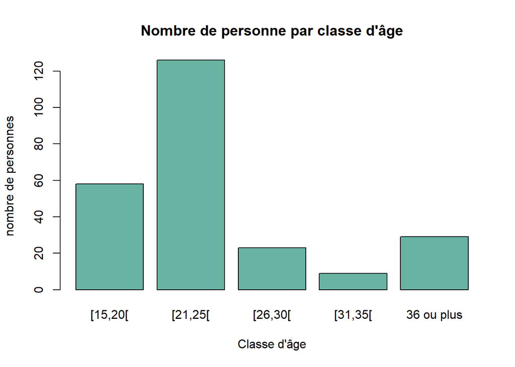

```r
library(dplyr)
lbls2 <- c("[15,20[","[21,25[","[26,30[","[31,35[","36 ou plus")
df1 <- data.frame(df$age) %>% group_by(df$age) %>% count(df$age)
barplot(df1$n,names.arg=lbls2,col="#69b3a2",
        main="Nombre de personne par classe d'âge",
        xlab="Classe d'âge",
        ylab="nombre de personnes")
```

Dans cette étude, la classe d’âge avec le plus grand effectif est la classe [21ans;25ans[

**Classement des séries:**

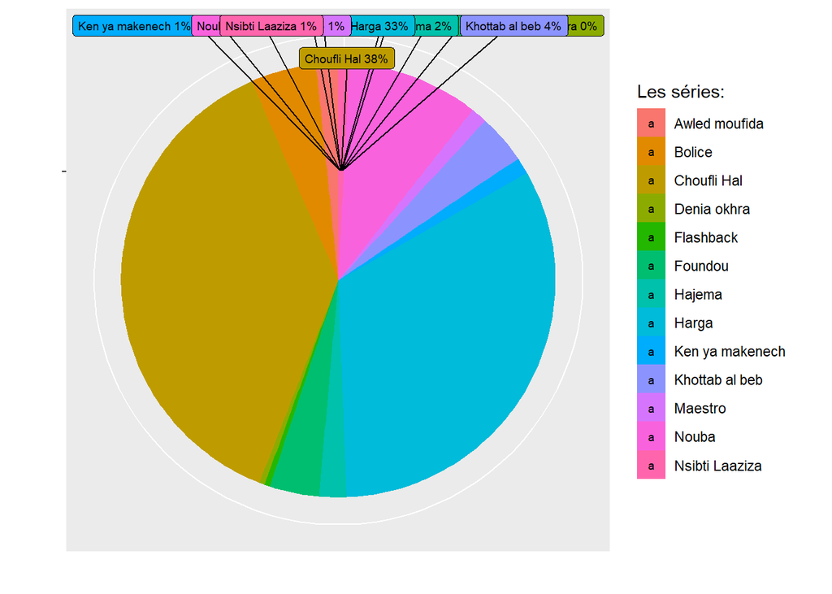

```r
library(dplyr)
library(ggplot2)
library(ggrepel)
serie <- df$serie
freq3=table(serie)/100
pct3 <- round(freq3/sum(freq3)*100)
lbls3 <- names(freq3)
lbls3 <- paste(lbls3, pct3)
lbls3 <- paste(lbls3,"%",sep="")
data2 <- as.data.frame(pct3)

ggplot(data1, aes(x = "", y = "Freq" , fill = serie)) +
  geom_col() +
  geom_label_repel(data = data2,
                   aes(label = lbls3),
                   size = 2.5, nudge_x = 1, show.legend = TRUE , max.overlaps = getOption("ggrepel.max.overlaps", default = 10)) +
  coord_polar(theta = "y")+
  guides(fill = guide_legend(title = "Les séries:"))+
  ylab("")+xlab("")
```

```r
lbls3
```

```
##  [1] "Awled moufida 2%"   "Bolice 5%"          "Choufli Hal 38%"
##  [4] "Denia okhra 0%"     "Flashback 0%"       "Foundou 4%"
##  [7] "Hajema 2%"          "Harga 33%"          "Ken ya makenech 1%"
## [10] "Khottab al beb 4%"  "Maestro 1%"         "Nouba 10%"
## [13] "Nsibti Laaziza 1%"
```

**La catégories socio-professionelle des télésectateurs:**

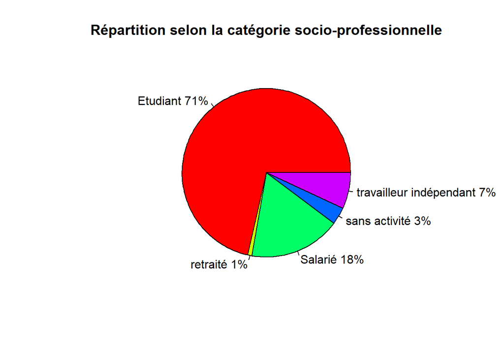

```r
csp<- df$csp
freq4<-table(csp)
pct4 <- round(freq4/sum(freq1)*100)
lbls4 <- names(freq4)
lbls4 <- paste(lbls4, pct4)
lbls4 <- paste(lbls4,"%",sep="")
pie(freq4,labels = lbls4, col=rainbow(length(lbls4))
    ,main="Répartition selon la catégorie socio-professionnelle")
```

### Analyse en composantes principales:

L’**ACP** permet de décrire un jeu de données et de regrouper les variables ainsi que les individus par des critéres communs.Le but de cette ACP est de trouver des groupements des variables et des individus permettant de mieux se renseigner sur les profils des téléspectateurs des séries tunisiennes ramadanesques. Pour réaliser cette ACP on a commencé par extraire la partie de la base sur laquelle l’acp sera effectuée.  
Cette ACP est effectuée sur une question de l’échelle de **Likert**, elle s’agit d’une mesure du niveau de satisfaction(de 1 à 5 : 1 - pas du tout satisfait 5-Tout à fait satisfait) des 245 téléspectateurs des séries tunisiennes ramadanesques:

```r
library(stringi)
first_CPA_df <- df[,23:37]
name <- function(ch) {
  stri_replace_all_regex(ch,"Sur.une.échelle.de.1.à.5...évaluez.chacune.de.ces.séries...","")
}
colnames(first_CPA_df)<- name(colnames(first_CPA_df))
head(first_CPA_df)
```

```
##   Choufli.Hal. Bolice. Nsibti.Laaziza. Denia.okhra. Hajema. Ken.ya.makenech.
## 1            5       2               3            2       1                3
## 2            5       3               2            1       3                1
## 3            2       2               1            1       1                1
## 4            5       2               1            2       3                2
## 5            3       2               3            1       1                1
## 6            5       2               5            3       3                3
##   Nouba. Maestro. Harga. Galb.edhib. Khottab.aal.beb. Foundou. Chouerreb.
## 1      5        2      2           3                2        5          3
## 2      2        5      5           1                2        2          2
## 3      1        3      2           1                3        1          1
## 4      2        2      2           2                2        3          3
## 5      2        5      1           1                5        1          2
## 6      3        2      3           3                5        3          3
##   Flashback. Awled.moufida.
## 1          2              5
## 2          2              2
## 3          1              1
## 4          2              2
## 5          1              3
## 6          3              3
```

1.La commande de l’**ACP** :

```r
library(FactoMineR)
res.pca1 <- PCA (first_CPA_df,graph=FALSE)
```

2.Le nombre d’axe à conserver:  
Les valeurs propres mesurent la quantité de variance expliquée par chaque axe principal. Les valeurs propres sont grandes pour les premiers axes et petits pour les axes suivants. Autrement dit, les premiers axes correspondent aux directions portant la quantité maximale de variation contenue dans le jeu de données. on commence par le critére du taux d’inertie cumulé et du critère de **Kaiser**:

```r
library(factoextra)
eig.val1 <- get_eigenvalue(res.pca1)
eig.val1
```

```
##        eigenvalue variance.percent cumulative.variance.percent
## Dim.1   3.0928270        20.618847                    20.61885
## Dim.2   1.9312044        12.874696                    33.49354
## Dim.3   1.2977006         8.651337                    42.14488
## Dim.4   1.1502882         7.668588                    49.81347
## Dim.5   0.9739054         6.492703                    56.30617
## Dim.6   0.9064347         6.042898                    62.34907
## Dim.7   0.8513135         5.675423                    68.02449
## Dim.8   0.7723643         5.149095                    73.17359
## Dim.9   0.7165336         4.776891                    77.95048
## Dim.10  0.6857090         4.571394                    82.52187
## Dim.11  0.6383698         4.255798                    86.77767
## Dim.12  0.6338577         4.225718                    91.00339
## Dim.13  0.5261231         3.507488                    94.51088
## Dim.14  0.4354694         2.903129                    97.41401
## Dim.15  0.3878992         2.585995                   100.00000
```

d’aprés la table qui précède , on remarque que le taux d’inertie cumulé nous donne 49% des informations à partir de la dimension 4 .Selon **le critére de Kaiser** ,on ne retient que les axes dont l’inertie est supérieure à l’inertie moyenne I/p (qui présente en ACP normée: I/p= 1 : On ne retiendra que les axes associés à des valeurs propre supérieures à 1 .Le nombre d’axe à retenir est 4 selon le critère de **Kaiser**:

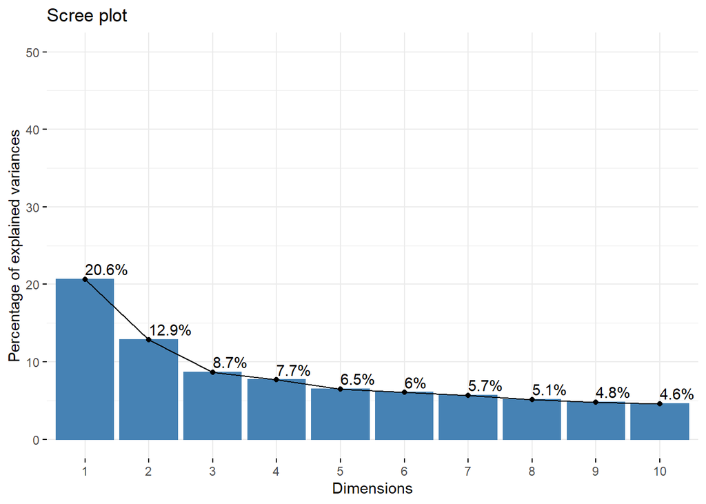

```r
library(factoextra)
fviz_eig(res.pca1, addlabels = TRUE, ylim = c(0, 50))
```

D’aprés **le critére du Coude** et sur l’éboulis des valeurs propres, on observe un décrochement (coude) suivi d’une décroissance régulière. On sélectionne les axes avant le décrochement. Selon le tracé de l’éboulis présenté ci-dessus, le nombre d’axe à conserver est de 3.  
D’aprés ces trois critères le nombre d’axe à conserver est de 4 axes.  
**Etude des variables:**  
Aprés avoir choisi le nombre d’axe à conserver, on commence l’étude des variables et des individus afin d’aboutir aux cartes des variables et des individus et les interpréter. Pour interpréter les axes, on commence par extraire les variables, dans un premier lieu.

```r
library(factoextra)
var1 <- get_pca_var(res.pca1)
var1
```

```
## Principal Component Analysis Results for variables
##  ===================================================
##   Name       Description
## 1 "$coord"   "Coordinates for the variables"
## 2 "$cor"     "Correlations between variables and dimensions"
## 3 "$cos2"    "Cos2 for the variables"
## 4 "$contrib" "contributions of the variables"
```

les résultats présentés ci-dessus sont les résultat obtenus pour les variables actives (coordonnées, corrélation entre variables et les axes, cosinus-carré et contributions) qui serviront pour présenter les cartes des variables ainsi que les contributions à chacun des axes et les qualitées de présentations de celles-ci.  
**Cercle de corrélation:**  
La corrélation entre une variable et une composante principale est utilisée comme coordonnées de la variable sur la composante principale.La représentation des variables se fait à travers les corrélations.

```r
var1$coord
```

```
##                       Dim.1        Dim.2       Dim.3        Dim.4       Dim.5
## Choufli.Hal.     0.35203124 -0.117332768  0.08037179  0.604381839 -0.45123803
## Bolice.          0.28893512 -0.123598592  0.71512033 -0.133699031  0.09286901
## Nsibti.Laaziza.  0.12050503  0.398150958 -0.10837552  0.588168354  0.25579488
## Denia.okhra.     0.06246283  0.481397363  0.12108488  0.272310472  0.45614305
## Hajema.          0.38702038 -0.195527350  0.59595573  0.154072051 -0.03325482
## Ken.ya.makenech. 0.41633066 -0.210872056  0.25263344  0.153643170  0.03523038
## Nouba.           0.56155293 -0.234454353 -0.08227307  0.055605540  0.39238891
## Maestro.         0.57436736 -0.501839439 -0.16048726 -0.159059228  0.08731558
## Harga.           0.61383109 -0.366329823 -0.21151813 -0.030027915 -0.03990187
## Galb.edhib.      0.53546409  0.007304281 -0.37883088  0.007709622  0.30270792
## Khottab.aal.beb. 0.60243584 -0.042661207 -0.30987767  0.131856116 -0.33936510
## Foundou.         0.38766943  0.630759660  0.04880912 -0.113742859 -0.27837404
## Chouerreb.       0.46861938  0.359116140  0.01450322 -0.442584891 -0.06035474
## Flashback.       0.58181367  0.288657384  0.12223312 -0.203908404  0.11033901
## Awled.moufida.   0.40472299  0.613324915 -0.01070865 -0.050591910 -0.15008315
```

Pour une interprétation plus claire, voila le graphique de corrélation des variables:

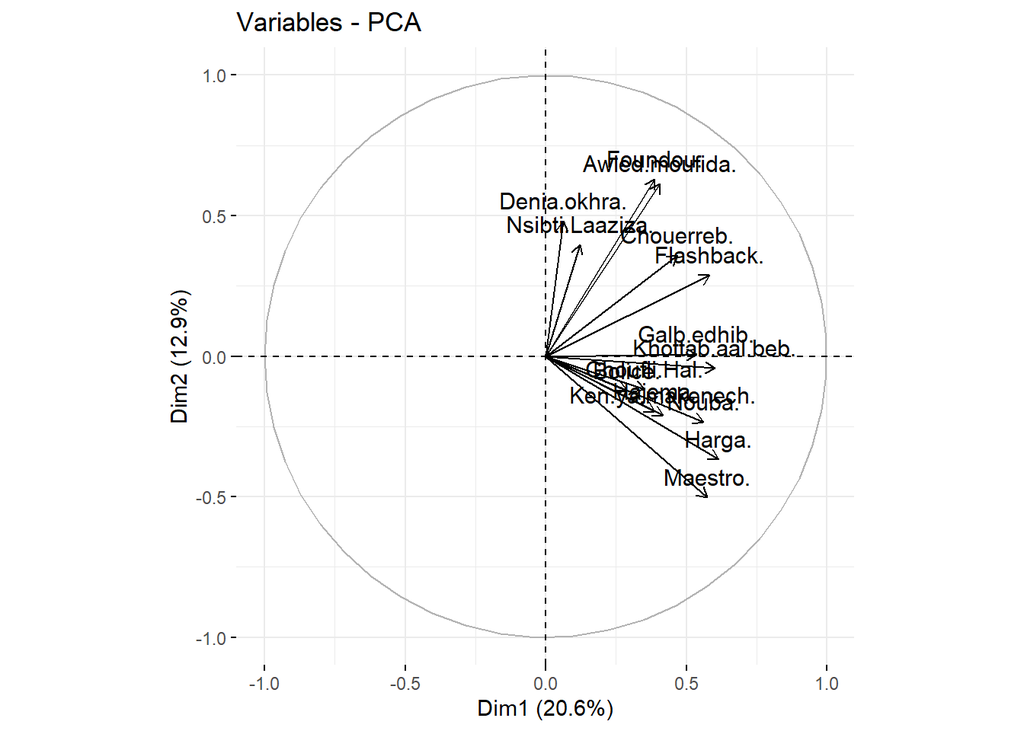

```r
library(factoextra)
fviz_pca_var(res.pca1, col.var = "black",axes = 1:2)
```

Le graphique peut être interprété comme suit:

1.Les variables positivement corrélées sont regroupées.  
2.Les variables négativement corrélées sont positionnées sur les côtés opposés de l’origine du graphique (quadrants opposés).  
3.La distance entre les variables et l’origine mesure la qualité de représentation des variables. Les variables qui sont loin de l’origine sont bien représentées par l’ACP.  
On voit dans le graphe qui précède que les séries groupés sont **Awled Moufida** - **Foundou** , **Chouerreb** - **Flashback** … Ces séries sont positivement corrélées donc regroupés : Ceci s’explique par les similarités se trouvant dans chaque groupement de séries . Par exemple,les deux séries **Awled Moufida** - **Foundou** s’agissent de deux séries réalisés par le même producteur et du même genre(Tragiques), les deux séries **Chouerreb** - **Flashback** sont deux séries comportant le même acteur qui est **Lotfi Abdelli**.

**Qualité des présentations:**  
La qualité de représentation des variables sur la carte de l’ACP s’appelle cos2 (cosinus carré) . Vous pouvez accéder au cos2 comme suit:

```r
head(var1$cos2)
```

```
##                        Dim.1      Dim.2       Dim.3      Dim.4       Dim.5
## Choufli.Hal.     0.123925997 0.01376698 0.006459624 0.36527741 0.203615757
## Bolice.          0.083483504 0.01527661 0.511397083 0.01787543 0.008624653
## Nsibti.Laaziza.  0.014521462 0.15852419 0.011745254 0.34594201 0.065431022
## Denia.okhra.     0.003901606 0.23174342 0.014661549 0.07415299 0.208066479
## Hajema.          0.149784778 0.03823094 0.355163228 0.02373820 0.001105883
## Ken.ya.makenech. 0.173331216 0.04446702 0.063823654 0.02360622 0.001241180
```

Pour visualiser le cos2 des variables sur toutes les dimensions on utilise le package corrplot:

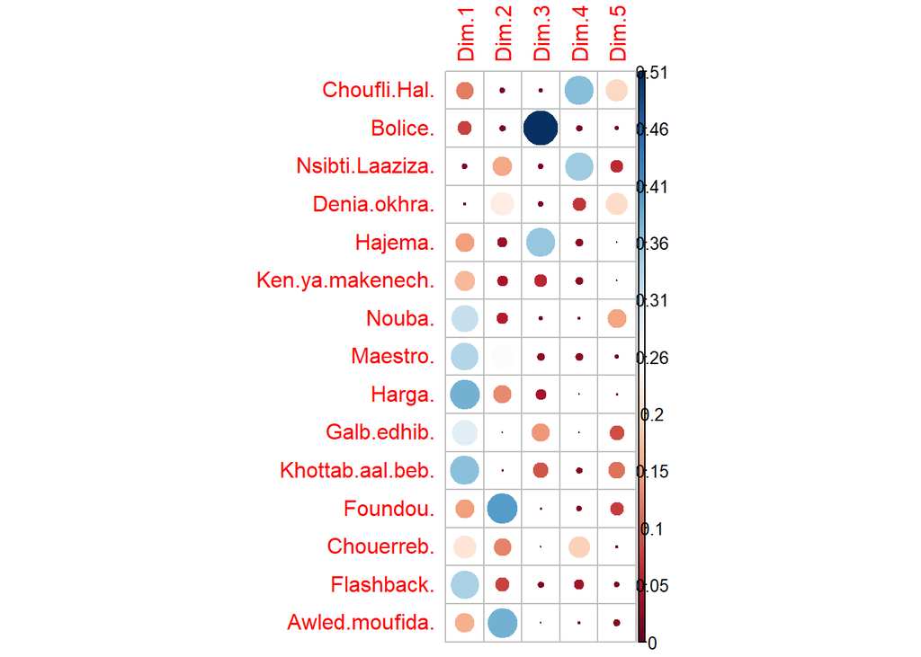

```r
library("corrplot")
corrplot(var1$cos2, is.corr=FALSE)
```

1.Un cos2 élevé indique une bonne représentation de la variable sur les axes principaux en considération. Dans ce cas, la variable est positionnée à proximité de la circonférence du cercle de corrélation.  
2.Un faible cos2 indique que la variable n’est pas parfaitement représentée par les axes principaux. Dans ce cas, la variable est proche du centre du cercle.  
Par exemple, la série **Bolice** est bien présenté sur le 3ème axe alors qu’elle est mal présentée sur le 5éme axe. Sa coordonnée sur le 3éme axe est plus importante pour interpréter les composantes principales en considération alors que sa coordonnée sur le 5éme est moins importatnte.  
Pour une interprétation encore plus claire des données on revient sur le graphique des corrélation et en mettant en relief la qualité de présentation de de chaque variable sur les axes principaux:

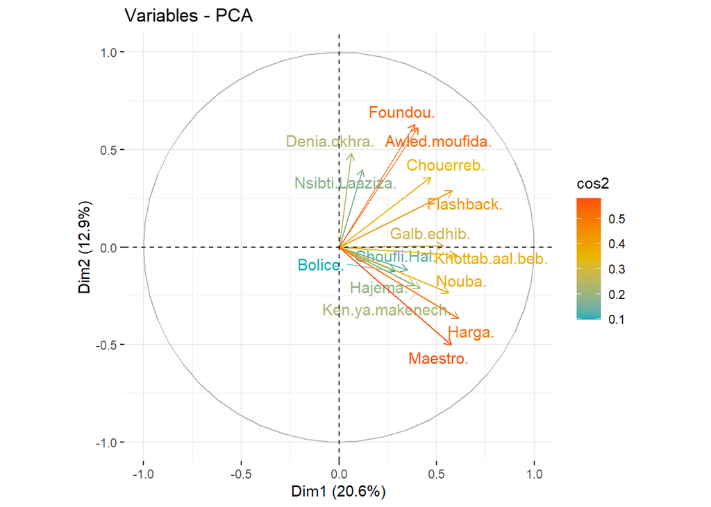

```r
library(factoextra)
fviz_pca_var(res.pca1, col.var = "cos2",
             gradient.cols = c("#00AFBB", "#E7B800", "#FC4E07"),
             repel = TRUE # Pour éviter le chevauchement de texte
             )
```

Les deux séries **Maestro** et **Harga** sont positivement corrélées et elles sont biens présentées sur les deux premiers axes donc elles sont bien contributives à l’interprétation: A part le fait qu’ils sont produit par le même producteur , les deux feuilletons traitent des problèmes qui touchent la sociétés donc ils attirent le même public qui cherche ce genre de feuilleton.

**La contribution des variables aux axes:**  
Le nombre important de variables (15) nécéssite la visualisation des contribution de chaque variable sur les axes.  
D’ailleurs:  
1.Les variables corrélées avec les 4 premiers axes sont les plus importantes pour expliquer la variabilité dans le jeu de données. Les variables qui ne sont pas en corrélation avec un axe ou qui sont corrélées avec les derniers axes sont des variables à faible apport et peuvent être supprimées pour simplifier l’analyse globale.  
La contribution des variables peut être extraite comme suit:

```r
var1$contrib
```

```
##                       Dim.1        Dim.2        Dim.3       Dim.4      Dim.5
## Choufli.Hal.      4.0068842  0.712870085  0.497774590 31.75529379 20.9071390
## Bolice.           2.6992620  0.791040657 39.407940046  1.55399582  0.8855740
## Nsibti.Laaziza.   0.4695207  8.208565922  0.905081945 30.07437649  6.7184166
## Denia.okhra.      0.1261501 11.999942763  1.129809782  6.44647064 21.3641364
## Hajema.           4.8429730  1.979642594 27.368656732  2.06367381  0.1135514
## Ken.ya.makenech.  5.6042971  2.302554000  4.918210947  2.05220075  0.1274436
## Nouba.           10.1959047  2.846350377  0.521604021  0.26880012 15.8094467
## Maestro.         10.6665474 13.040713054  1.984753698  2.19943466  0.7828286
## Harga.           12.1826603  6.948904003  3.447630391  0.07838694  0.1634819
## Galb.edhib.       9.2705408  0.002762655 11.059009320  0.00516725  9.4087253
## Khottab.aal.beb. 11.7345373  0.094240597  7.399562830  1.51145034 11.8254477
## Foundou.          4.8592303 20.601535022  0.183580863  1.12471271  7.9568410
## Chouerreb.        7.1004333  6.677926112  0.016208936 17.02889593  0.3740296
## Flashback.       10.9449106  4.314565870  1.151339107  3.61462771  1.2500904
## Awled.moufida.    5.2961480 19.478386289  0.008836794  0.22251305  2.3128479
```

Cette contribution peut être visualisé à travers ce graphe:

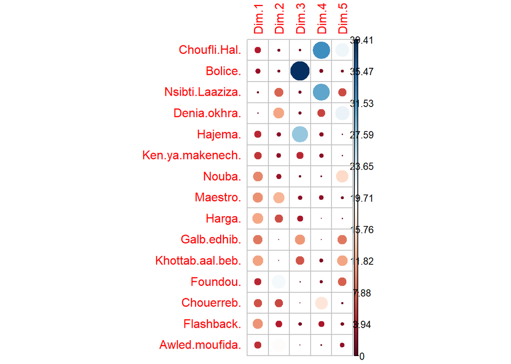

```r
library(corrplot)
corrplot(var1$contrib, is.corr=FALSE)
```

La contribution est relative à chaque axe .Prenant l’exemple du 1er axe et du 2ème axe:

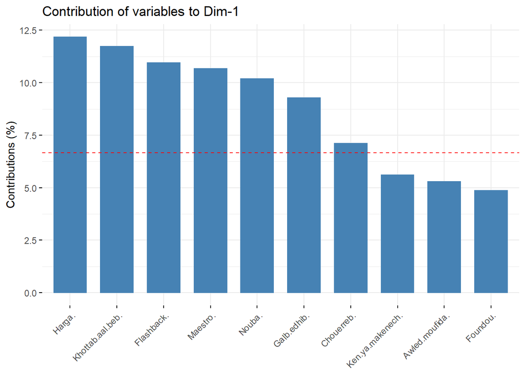

```r
library(factoextra)
fviz_contrib(res.pca1, choice = "var", axes = 1, top = 10)
```

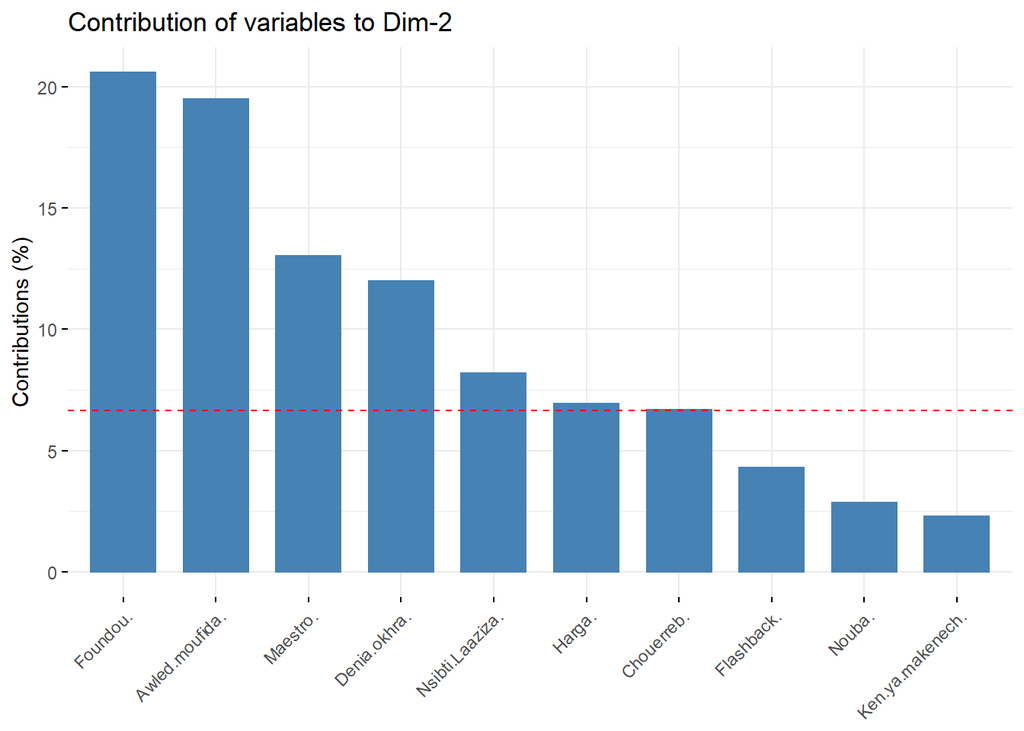

```r
library(factoextra)
fviz_contrib(res.pca1, choice = "var", axes = 2, top = 10)
```

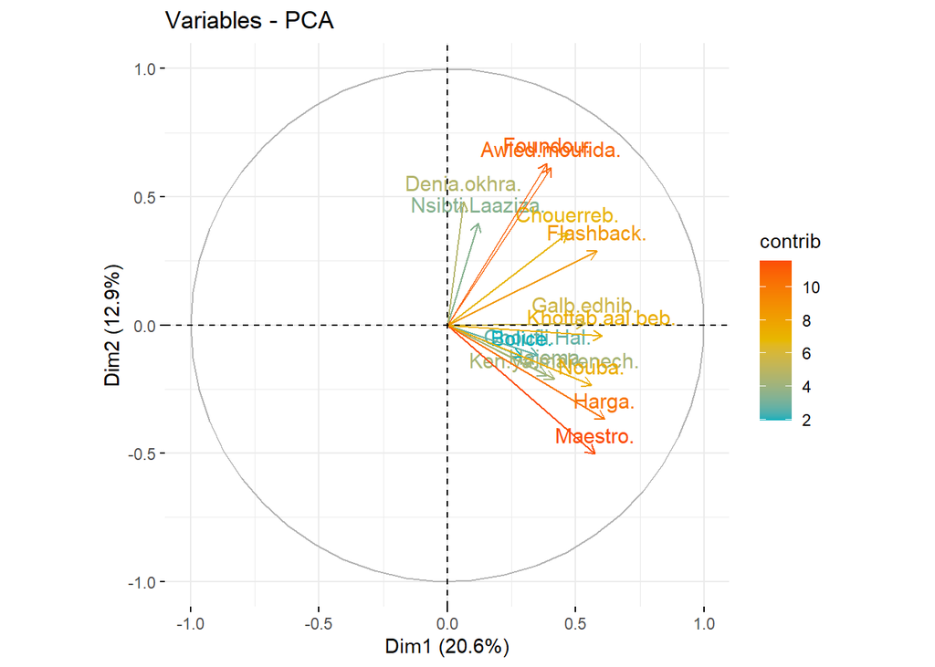

```r
fviz_pca_var(res.pca1, col.var = "contrib",
             gradient.cols = c("#00AFBB", "#E7B800", "#FC4E07")
             )
```

**Description des dimensions:**  
Cette étude peut être utilisée pour identifier les variables les plus significativement associées avec une composante principale donnée Elle peut être utilisée comme suit:(2 premiers axes)

```r
library(FactoMineR)
res.desc <- dimdesc(res.pca1, axes = c(1,2), proba = 0.05)
res.desc$Dim.1
```

```
## $quanti
##                  correlation      p.value
## Harga.             0.6138311 9.246038e-27
## Khottab.aal.beb.   0.6024358 1.363164e-25
## Flashback.         0.5818137 1.362430e-23
## Maestro.           0.5743674 6.639005e-23
## Nouba.             0.5615529 9.238646e-22
## Galb.edhib.        0.5354641 1.401583e-19
## Chouerreb.         0.4686194 8.872599e-15
## Ken.ya.makenech.   0.4163307 1.088812e-11
## Awled.moufida.     0.4047230 4.503492e-11
## Foundou.           0.3876694 3.290537e-10
## Hajema.            0.3870204 3.541391e-10
## Choufli.Hal.       0.3520312 1.475959e-08
## Bolice.            0.2889351 4.268451e-06
##
## attr(,"class")
## [1] "condes" "list"
```

```r
res.desc$Dim.2
```

```
## $quanti
##                  correlation      p.value
## Foundou.           0.6307597 1.379190e-28
## Awled.moufida.     0.6133249 1.044415e-26
## Denia.okhra.       0.4813974 1.286794e-15
## Nsibti.Laaziza.    0.3981510 9.823141e-11
## Chouerreb.         0.3591161 7.187370e-09
## Flashback.         0.2886574 4.364043e-06
## Hajema.           -0.1955274 2.108089e-03
## Ken.ya.makenech.  -0.2108721 8.962663e-04
## Nouba.            -0.2344544 2.132614e-04
## Harga.            -0.3663298 3.391815e-09
## Maestro.          -0.5018394 4.933324e-17
##
## attr(,"class")
## [1] "condes" "list"
```

Le 1er axe est fortement corrélé positivement avec les feuilletons **Harga**, **Khottab al beb** ,**Flashback** et **Maestro** qui sont des feuilletons tragiques, alors qu’il est corrélés d’une manière moins importante avec**Choufli Hal** ,**Hajema** et **Bolice**.Si on devrait donner un nom à cet axe , il serait l’axe “Tragique”.  
Le 2éme axe est fortement corrélé positivement avec les feuilletons **Foundou** , **Awled Moufida** , **Denia okhra** et il est corrélé négativement avec **Nouba** , **Harga** et **Maestro**. Donc cet axe peut présenter les feuilletons de la chaîne télévisée **ElHiwar Ettounsi**.

**Graphique des individus:**  
La visualisation des individus se fait à travers la fonction:

```r
library(factoextra)
ind1 <- get_pca_ind(res.pca1)
ind1
```

```
## Principal Component Analysis Results for individuals
##  ===================================================
##   Name       Description
## 1 "$coord"   "Coordinates for the individuals"
## 2 "$cos2"    "Cos2 for the individuals"
## 3 "$contrib" "contributions of the individuals"
```

Cette fonction, tout comme celle des variables, retourne une liste de matrices contenant tous les résultats pour les individus (coordonnées, corrélation entre individus et axes, cosinus-carré et contributions)  
Comme les variables, il est également possible de colorer les individus en fonction de leurs valeurs de cos2:

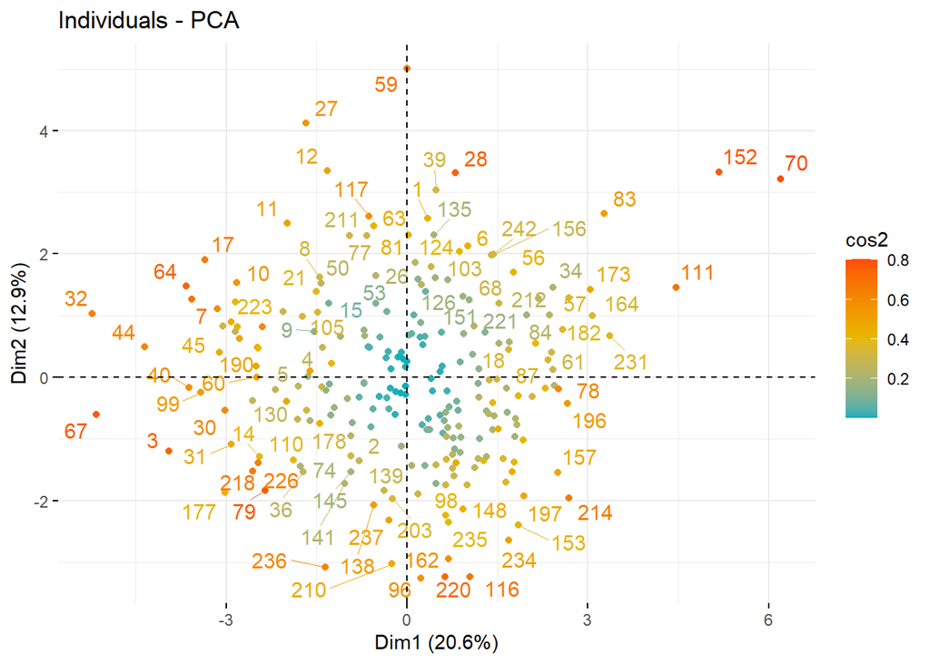

```
Vous pouvez également modifier la taille des points en fonction du cos2 des individus correspondants:
```

```r
fviz_pca_ind (res.pca1, col.ind = "cos2",
             gradient.cols = c("#00AFBB", "#E7B800", "#FC4E07"),
             repel = TRUE
             )
```

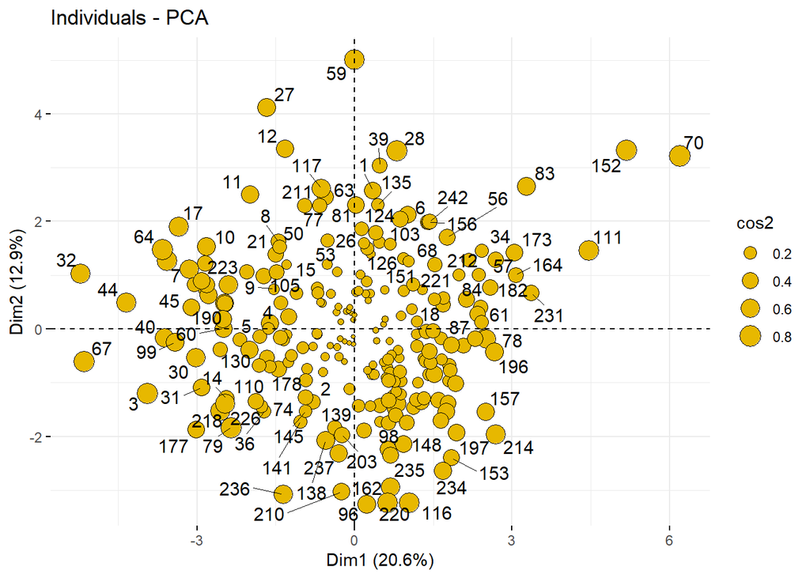

```r
fviz_pca_ind (res.pca1, pointsize = "cos2",
             pointshape = 21, fill = "#E7B800",
             repel = TRUE
             )
```

Enfin , voici le biplot qui présente les variables et les individus,il nous renseigne sur la relation entre ces derniers:

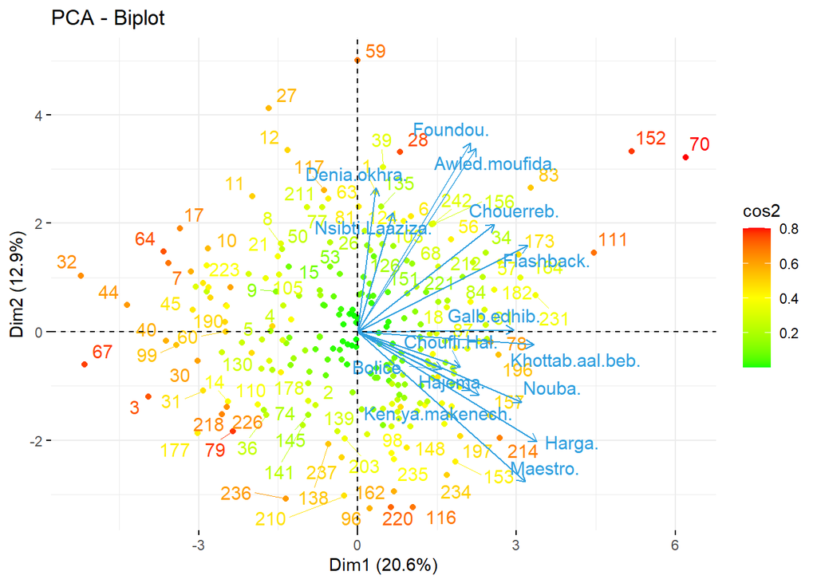

```r
fviz_pca_biplot (res.pca1, col.ind = "cos2",
              gradient.cols = c("green", "yellow", "red"),
              col.var = "#2E9FDF",
              repel = TRUE
)
```

### Analyse factorielle des correspondances:

L’analyse factorielle des correspondances sert comme outil pour analyser les correspondances entre deux variables qualitatives.Dans cette étude j’ai choisi d’étudier le choix de la série par classe d’âge.L’AFC permet de résumer et de visualiser l’information contenue dans le tableau de contingence formé par les deux variables catégorielles. Le tableau de contingence contient les fréquences formées par les deux variables.Lors de l’analyse d’un tableau de contingence, une question typique est de savoir si certains éléments lignes sont associés à certains éléments colonnes. L’analyse factorielle par correspondance est une approche géométrique pour visualiser les lignes et les colonnes d’une table de contingence dans un graphique en nuage de points, de sorte que les positions des points lignes et celles des points colonnes correspondent à leurs associations dans le tableau.Dans ce qui suit je montrerai comment calculer et interpréter l’AFC en utilisant deux packages R:  
i) **FactoMineR:** pour l’analyse  
ii)**factoextra:** pour la visualisation des données.  
**Construction du tableau crois´e et des tableaux des profils:** Commençons par le tableau croisé:

```r
tab<-table(df$age,df$serie)
tab
```

```
##
##           Awled moufida Bolice Choufli Hal Denia okhra Flashback Foundou Hajema
##   [15;20[             3      4          16           0         0       2      0
##   [20;25[             1      3          51           0         0       5      4
##   [25;30[             0      2          10           0         0       0      1
##   [30;35[             0      1           2           0         0       0      0
##   ++36                0      2          13           1         1       2      0
##
##           Harga Ken ya makenech Khottab al beb Maestro Nouba Nsibti Laaziza
##   [15;20[    26               0              0       0     7              0
##   [20;25[    41               0              6       2    12              1
##   [25;30[     7               1              1       0     1              0
##   [30;35[     3               0              1       0     2              0
##   ++36        3               2              1       1     2              1
```

**Puis par le tableau des fréquences:**

```r
f<-round(100*tab/sum(tab),1)
f
```

```
##
##           Awled moufida Bolice Choufli Hal Denia okhra Flashback Foundou Hajema
##   [15;20[           1.2    1.6         6.5         0.0       0.0     0.8    0.0
##   [20;25[           0.4    1.2        20.8         0.0       0.0     2.0    1.6
##   [25;30[           0.0    0.8         4.1         0.0       0.0     0.0    0.4
##   [30;35[           0.0    0.4         0.8         0.0       0.0     0.0    0.0
##   ++36              0.0    0.8         5.3         0.4       0.4     0.8    0.0
##
##           Harga Ken ya makenech Khottab al beb Maestro Nouba Nsibti Laaziza
##   [15;20[  10.6             0.0            0.0     0.0   2.9            0.0
##   [20;25[  16.7             0.0            2.4     0.8   4.9            0.4
##   [25;30[   2.9             0.4            0.4     0.0   0.4            0.0
##   [30;35[   1.2             0.0            0.4     0.0   0.8            0.0
##   ++36      1.2             0.8            0.4     0.4   0.8            0.4
```

et les tableaux profils-lignes et profils-colonnes:

```r
library(questionr)
pl<-lprop(tab)
pl
```

```
##
##            Awled moufida Bolice Choufli Hal Denia okhra Flashback Foundou
##   [15;20[    5.2           6.9   27.6         0.0         0.0       3.4
##   [20;25[    0.8           2.4   40.5         0.0         0.0       4.0
##   [25;30[    0.0           8.7   43.5         0.0         0.0       0.0
##   [30;35[    0.0          11.1   22.2         0.0         0.0       0.0
##   ++36       0.0           6.9   44.8         3.4         3.4       6.9
##   Ensemble   1.6           4.9   37.6         0.4         0.4       3.7
##
##            Hajema Harga Ken ya makenech Khottab al beb Maestro Nouba
##   [15;20[    0.0   44.8   0.0             0.0            0.0    12.1
##   [20;25[    3.2   32.5   0.0             4.8            1.6     9.5
##   [25;30[    4.3   30.4   4.3             4.3            0.0     4.3
##   [30;35[    0.0   33.3   0.0            11.1            0.0    22.2
##   ++36       0.0   10.3   6.9             3.4            3.4     6.9
##   Ensemble   2.0   32.7   1.2             3.7            1.2     9.8
##
##            Nsibti Laaziza Total
##   [15;20[    0.0          100.0
##   [20;25[    0.8          100.0
##   [25;30[    0.0          100.0
##   [30;35[    0.0          100.0
##   ++36       3.4          100.0
##   Ensemble   0.8          100.0
```

Comme le montre le tableau des profils-lignes: 44.8% des personnes âgés entre 15ans et 20ans regardent **Harga** et 44.8% des gens âgés de plus de 36ans ont choisi **Choufli Hal** .  
Le tableau de profils-colonnes:

```r
library(questionr)
pc<-cprop(tab)
pc
```

```
##
##           Awled moufida Bolice Choufli Hal Denia okhra Flashback Foundou Hajema
##   [15;20[  75.0          33.3   17.4         0.0         0.0      22.2     0.0
##   [20;25[  25.0          25.0   55.4         0.0         0.0      55.6    80.0
##   [25;30[   0.0          16.7   10.9         0.0         0.0       0.0    20.0
##   [30;35[   0.0           8.3    2.2         0.0         0.0       0.0     0.0
##   ++36      0.0          16.7   14.1       100.0       100.0      22.2     0.0
##   Total   100.0         100.0  100.0       100.0       100.0     100.0   100.0
##
##           Harga Ken ya makenech Khottab al beb Maestro Nouba Nsibti Laaziza
##   [15;20[  32.5   0.0             0.0            0.0    29.2   0.0
##   [20;25[  51.2   0.0            66.7           66.7    50.0  50.0
##   [25;30[   8.8  33.3            11.1            0.0     4.2   0.0
##   [30;35[   3.8   0.0            11.1            0.0     8.3   0.0
##   ++36      3.8  66.7            11.1           33.3     8.3  50.0
##   Total   100.0 100.0           100.0          100.0   100.0 100.0
##
##           Ensemble
##   [15;20[  23.7
##   [20;25[  51.4
##   [25;30[   9.4
##   [30;35[   3.7
##   ++36     11.8
##   Total   100.0
```

```
Parmis les personnes qui regardent le feuilleton **Awled Moufida** on a 75% qui sont âgés de 15ans à 20ans et 25% qui sont âgés de 20ans à 25ans.
```

Pour un petit tableau de contingence, vous pouvez utiliser le test de khi2 pour évaluer s’il existe une dépendance significative entre les catégories des lignes et des colonnes:

```r
chisq <- chisq.test(tab)
chisq
```

```
##
##  Pearson's Chi-squared test
##
## data:  tab
## X-squared = 64.121, df = 48, p-value = 0.05975
```

```
**Calcul de l'AFC:**
```

```r
library (FactoMineR)
res.ca <- CA (tab, graph = FALSE)
summary(res.ca)
```

```
##
## Call:
## CA(X = tab, graph = FALSE)
##
## The chi square of independence between the two variables is equal to 64.12073 (p-value =  0.05975143 ).
##
## Eigenvalues
##                        Dim.1   Dim.2   Dim.3   Dim.4
## Variance               0.158   0.058   0.026   0.019
## % of var.             60.530  22.247   9.961   7.262
## Cumulative % of var.  60.530  82.777  92.738 100.000
##
## Rows
##                   Iner*1000     Dim.1     ctr    cos2     Dim.2     ctr    cos2
## [15;20[         |    61.577 |  -0.347  18.036   0.464 |   0.371  55.852   0.528
## [20;25[         |    26.154 |  -0.080   2.079   0.126 |  -0.194  33.402   0.744
## [25;30[         |    24.336 |   0.108   0.696   0.045 |  -0.130   2.709   0.065
## [30;35[         |    20.720 |  -0.213   1.051   0.080 |   0.026   0.044   0.001
## ++36            |   128.932 |   1.023  78.137   0.960 |   0.198   7.994   0.036
##                     Dim.3     ctr    cos2
## [15;20[         |   0.019   0.315   0.001 |
## [20;25[         |   0.081  13.081   0.130 |
## [25;30[         |  -0.447  71.912   0.770 |
## [30;35[         |  -0.306  13.155   0.166 |
## ++36            |   0.058   1.537   0.003 |
##
## Columns (the 10 first)
##                   Iner*1000    Dim.1    ctr   cos2    Dim.2    ctr   cos2
## Awled moufida   |    24.451 | -0.705  5.121  0.332 |  0.951 25.334  0.603 |
## Bolice          |    15.208 |  0.088  0.238  0.025 |  0.367 11.332  0.434 |
## Choufli Hal     |    12.278 |  0.118  3.288  0.424 | -0.120  9.214  0.437 |
## Denia okhra     |    30.401 |  2.569 17.008  0.886 |  0.822  4.734  0.091 |
## Flashback       |    30.401 |  2.569 17.008  0.886 |  0.822  4.734  0.091 |
## Foundou         |     8.300 |  0.265  1.632  0.311 |  0.076  0.367  0.026 |
## Hajema          |    13.684 | -0.106  0.146  0.017 | -0.752 19.830  0.844 |
## Harga           |    28.935 | -0.287 16.931  0.927 |  0.074  3.077  0.062 |
## Ken ya makenech |    48.225 |  1.804 25.145  0.826 |  0.369  2.860  0.035 |
## Khottab al beb  |    16.019 |  0.122  0.347  0.034 | -0.494 15.368  0.559 |
##                  Dim.3    ctr   cos2
## Awled moufida    0.213  2.832  0.030 |
## Bolice          -0.394 29.220  0.501 |
## Choufli Hal      0.009  0.106  0.002 |
## Denia okhra      0.360  2.033  0.017 |
## Flashback        0.360  2.033  0.017 |
## Foundou          0.386 20.983  0.659 |
## Hajema          -0.150  1.763  0.034 |
## Harga           -0.004  0.017  0.000 |
## Ken ya makenech -0.682 21.869  0.118 |
## Khottab al beb  -0.142  2.822  0.046 |
```

**Choix du nombre d’axe:**

```r
library(factoextra)
eig.val <- res.ca$eig
round(res.ca$eig,3)
```

```
##       eigenvalue percentage of variance cumulative percentage of variance
## dim 1      0.158                 60.530                            60.530
## dim 2      0.058                 22.247                            82.777
## dim 3      0.026                  9.961                            92.738
## dim 4      0.019                  7.262                           100.000
```

Pour trancher les nombre d’axe à choisir , on a recours au graphique des valeurs propres:

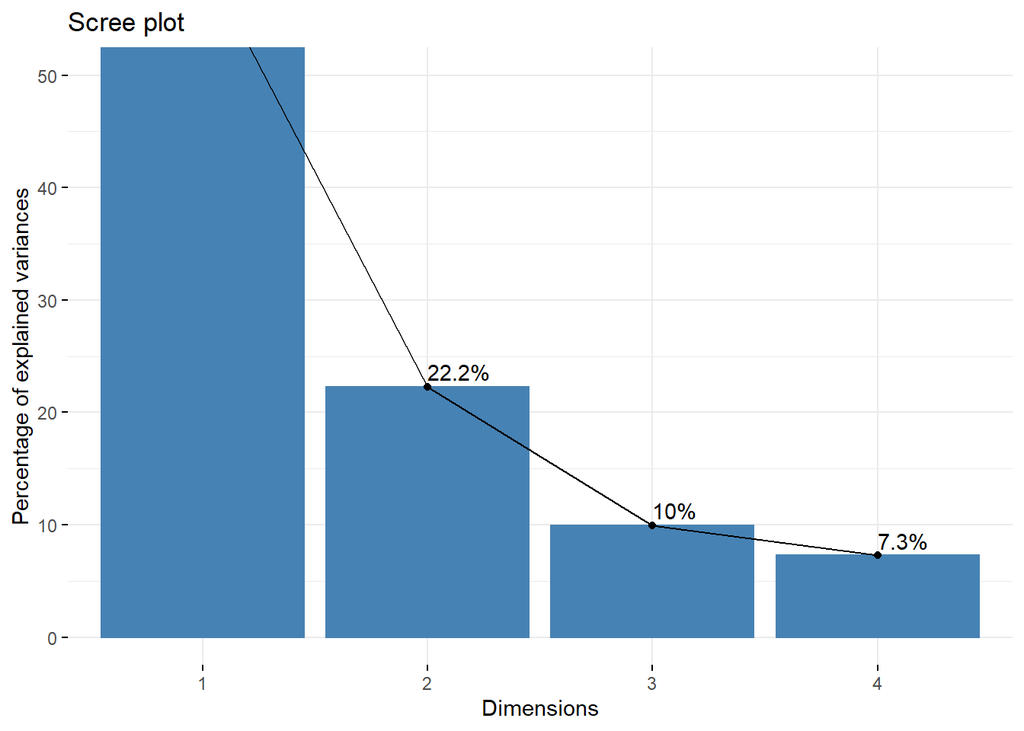

```r
library(factoextra)
fviz_screeplot (res.ca, addlabels = TRUE, ylim = c(0, 50) )
```

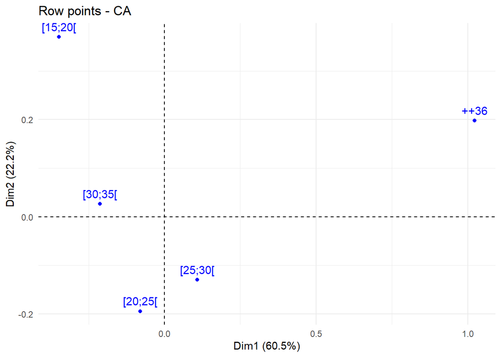

```r
library(factoextra)
row <- get_ca_row(res.ca)
fviz_ca_row(res.ca, col.col = "contrib")+scale_color_gradient2(low = "white", mid = "blue", high = "red", midpoint = 25) + theme_minimal()
```

```r
col <- get_ca_col(res.ca)
col
```

```
## Correspondence Analysis - Results for columns
##  ===================================================
##   Name       Description
## 1 "$coord"   "Coordinates for the columns"
## 2 "$cos2"    "Cos2 for the columns"
## 3 "$contrib" "contributions of the columns"
## 4 "$inertia" "Inertia of the columns"
```

**Graphiques: qualité et contribution**  
Ce graphique présente la carte des colonne (séries).Les points sont colorés en fonction de leurs cos2:

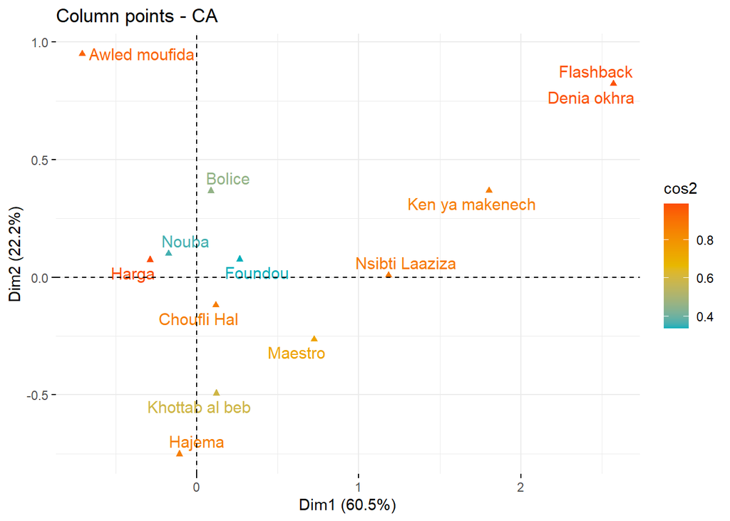

```r
library(factoextra)
fviz_ca_col (res.ca, col.col = "cos2",
             gradient.cols = c("#00AFBB", "#E7B800", "#FC4E07"),
             repel = TRUE)
```

Plot selon les contributions:

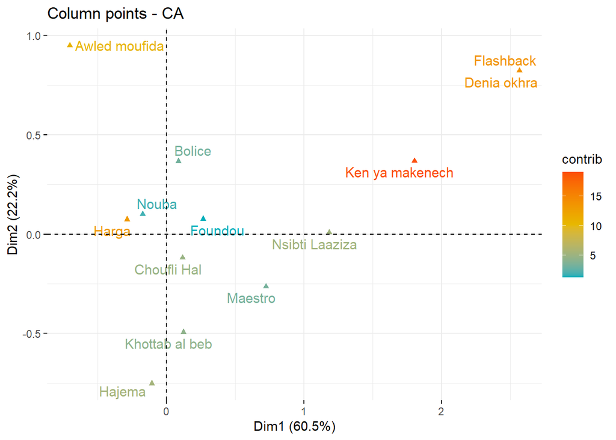

```r
library(factoextra)
fviz_ca_col (res.ca, col.col = "contrib",
             gradient.cols = c("#00AFBB", "#E7B800", "#FC4E07"),
             repel = TRUE)
```

Comme on le voit trés bien, l’axe 2 oppose les deux feuilleton **Awled Moufida** et **Hajema**.  
**Carte de représentation simultanée**

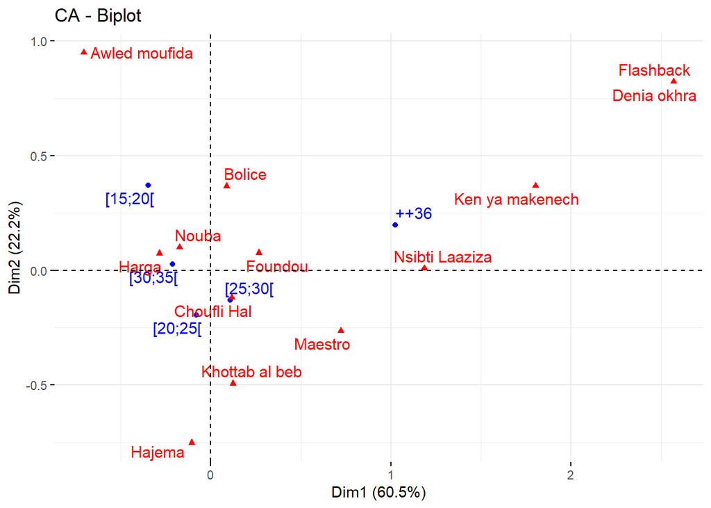

```r
library(factoextra)
fviz_ca_biplot(res.ca, repel = TRUE)
```

La carte de représentation simultané présente une correspondance entre la classe d’âge de 25ans à 30ans et le fameux feuilleton **Choufli Hal**. Cette correspondance est du au fait que ce feuilleton a eu un succés lors de son apparition(2006) et les téléspectateurs qui l’ont regardé continuent à le faire de nos jours et ces téléspectateurs ont des âges qui varient entre 25ans et 30ans.Cette AFC présente aussi une correspondance entre la classe d’âge 30ans à 35ans et **Harga**,Ceci est dû au fait que cette série touche un problème de la société qui est l’immigration illégale qui touche surtout la tranche d’âge entre 30ans et 35ans.  
On peut aussi observer une correspondance entre **Bolice** et la tranche d’âge 15ans à 20ans et ceci est dû à ce que les jeunes de 15ans à 20ans ont tendance à regarder les séries commédiennes plutot que tragiques.